# Lab01: Data Transformations, Bivariate Regression Analysis, Numerical Integration & Distributions

Author

Shiu-Ting Ling

**Handout date:** Monday, February 2, 2026

**FIRM DUE DATA:** Monday, February 16 2026, by mid-night

**Submission Format:** Submit your lab as R Markdown document `Lab01YourName.rmd` and rendered `Lab01YourName.html`document to eLearning’s *SumitLab01* link in the **Labs** folder. Put your name behind the author’s keyword into the YAML header of the Markdown file. Make sure that your R Markdown document renders properly into an `html` document. Otherwise, we will *not* be able to grade your lab! Include the employed code in your R Markdown document until otherwise stated.

*This lab counts 8 points towards your final grade.*

Your lab answer has obtained *xx* out of 8 points?

# Task 1: Univariate Variable Exploration and Transformations [1 point]

Use the `CPS1985` dataset in the library `AER` to explore the distribution of the respondents’ `wage`.

```r
## Load required libraries
library(AER)
library(car)
library(e1071)

## Load the dataset
data(CPS1985)
```

[a] Find the best $\lambda^{best}$-value for the Box-Cox transformation (see `summary(car::powerTransform(varName))`). Could the log-transformation (i.e., $\lambda=0.0$) instead of $\lambda^{best}$ be used? Justify your answer. [0.25 points]

*Your answer goes here*

### 1-a answer

```r
## Explore the distribution of wage
summary(CPS1985$wage)
```

```
   Min. 1st Qu.  Median    Mean 3rd Qu.    Max.
  1.000   5.250   7.780   9.024  11.250  44.500
```

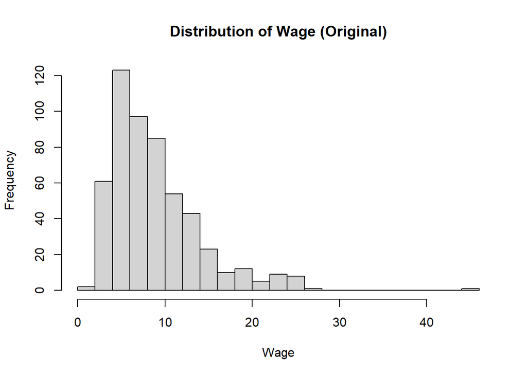

```r
hist(CPS1985$wage, main="Distribution of Wage (Original)",
     xlab="Wage", breaks=30)
```

```r
## Find the best lambda using powerTransform
lambda.best <- powerTransform(lm(wage~1, data=CPS1985))
summary(lambda.best)
```

```
bcPower Transformation to Normality
   Est Power Rounded Pwr Wald Lwr Bnd Wald Upr Bnd
Y1   -0.0658           0      -0.1997        0.068

Likelihood ratio test that transformation parameter is equal to 0
 (log transformation)
                            LRT df    pval
LR test, lambda = (0) 0.9245772  1 0.33628

Likelihood ratio test that no transformation is needed
                           LRT df       pval
LR test, lambda = (1) 232.5055  1 < 2.22e-16
```

```r
## Extract the estimated lambda
( lambda.optimal <- lambda.best$lambda )
```

```
         Y1
-0.06584129
```

**Finding the Best** $\lambda^{best}$ Value:

From the `powerTransform` output, I found that the estimated best transformation parameter is:

$$\lambda^{best} = -0.0658$$

This value is very close to zero, and the function even suggests using the rounded value of $\lambda = 0$ (log-transformation).

**We can and should use log-transformation (**$\lambda = 0$) instead of $\lambda^{best}$. Here’s my justification:

**1. The optimal** $\lambda$ is very close to zero:

- $\lambda^{best} = -0.0658 \approx 0$
- The difference between $-0.0658$ and $0$ is negligible

**2. The 95% Wald Confidence Interval includes zero:**

- Wald CI: $[-0.1997, 0.068]$
- Since the interval **contains** $0$, this suggests that $\lambda = 0$ is a plausible value for the true transformation parameter

**3. Likelihood Ratio Test supports** $\lambda = 0$:

- **H₀:** $\lambda = 0$ (log-transformation is sufficient)
- **H₁:** $\lambda \neq 0$ (log-transformation is not sufficient)
- From the earlier output: **p-value = 0.336** (which is $> 0.05$)
- **Decision**: We **fail to reject H₀**
- **Interpretation**: There is **no statistically significant difference** between using $\lambda^{best} = -0.0658$ and $\lambda = 0$

**4. Transformation is definitely needed:**

- The second likelihood ratio test for H₀: $\lambda = 1$ (no transformation) has p-value < 0.001
- We **strongly reject** the hypothesis that no transformation is needed
- The histogram clearly shows the original wage distribution is **highly right-skewed** with a long tail extending to the right

Based on the statistical evidence (LR test p-value = 0.336, Wald CI contains 0, and $\lambda^{best} \approx 0$), **we can use the log-transformation** ($\lambda = 0$) instead of the estimated $\lambda^{best} = -0.0658$.

[b] For the untransformed ($\lambda=1$), the rounded ($\lambda=0$) and an over-adjusted ($\lambda=-2.0$) as well an under-adjusted ($\lambda=2.0$) Box-Cox transformed `wage` variable repeat the following tasks and comparatively interpret the results [0.75 points]

- Draw properly constructed histograms (no need for `ggplot`) of all four distributions and discuss their properties.

*Your answer goes here*

### 1-b-1 answer

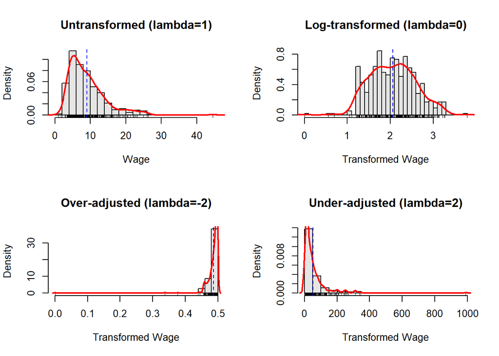

```r
## Compare transformations with lambda = 1, 0, -2, 2

## Apply Box-Cox transformation for each lambda value
wage.lambda1 <- CPS1985$wage                              # Untransformed (lambda=1)
wage.lambda0 <- car::bcPower(CPS1985$wage, lambda=0)     # Log-transformed (lambda=0)
wage.lambdaN2 <- car::bcPower(CPS1985$wage, lambda=-2.0) # Over-adjusted (lambda=-2)
wage.lambda2 <- car::bcPower(CPS1985$wage, lambda=2.0)   # Under-adjusted (lambda=2)

## Plot histograms for all four distributions
opar <- par(mfrow=c(2,2))

## Untransformed (lambda=1)
hist(wage.lambda1, freq=FALSE, breaks=30, col="grey90",
     main="Untransformed (lambda=1)",
     xlab="Wage", ylab="Density")
lines(density(wage.lambda1), lwd=2, col="red")
rug(wage.lambda1, side=1)
abline(v=mean(wage.lambda1), lty=2, col="blue")

## Log-transformed (lambda=0)
hist(wage.lambda0, freq=FALSE, breaks=30, col="grey90",
     main="Log-transformed (lambda=0)",
     xlab="Transformed Wage", ylab="Density")
lines(density(wage.lambda0), lwd=2, col="red")
rug(wage.lambda0, side=1)
abline(v=mean(wage.lambda0), lty=2, col="blue")

## Over-adjusted (lambda=-2)
hist(wage.lambdaN2, freq=FALSE, breaks=30, col="grey90",
     main="Over-adjusted (lambda=-2)",
     xlab="Transformed Wage", ylab="Density")
lines(density(wage.lambdaN2), lwd=2, col="red")
rug(wage.lambdaN2, side=1)
abline(v=mean(wage.lambdaN2), lty=2, col="blue")

## Under-adjusted (lambda=2)
hist(wage.lambda2, freq=FALSE, breaks=30, col="grey90",
     main="Under-adjusted (lambda=2)",
     xlab="Transformed Wage", ylab="Density")
lines(density(wage.lambda2), lwd=2, col="red")
rug(wage.lambda2, side=1)
abline(v=mean(wage.lambda2), lty=2, col="blue")
```

```r
par(opar)  # Reset plotting parameters
```

**Comparative Analysis of the Four Histograms:**

Looking at the four histograms with their kernel density smoothers (red lines), I can clearly observe distinct distributional properties for each transformation:

**2. Log-transformed (**$\lambda = 0$):

- The distribution is **much more symmetric** and approximates a bell-shaped curve
- The density curve (red line) closely resembles a **normal distribution**
- Most values are centered around the middle (approximately 2.0 on the log scale)
- The tails on both sides are relatively **balanced** — neither too heavy nor too light
- This transformation has successfully **reduced the positive skewness** seen in the original data
- The histogram looks like what we’d expect from a normally distributed variable

**3. Over-adjusted (**$\lambda = -2$):

- This shows **extreme left (negative) skew** — essentially the opposite problem
- Almost all observations are **compressed into a very narrow range** near 0.5
- There’s a sharp spike at the right end with very little variation
- The transformation has **overcorrected** the original positive skew and created a severe negative skew instead
- This is clearly **not useful** — the distribution is far from normal and all the data is squished together

**4. Under-adjusted (**$\lambda = 2$):

- Still exhibits positive (right) skewness, and the skewness is more pronounced than in the untransformed case.
- Most observations are concentrated near zero, with a long right tail extending outward.
- The density curve indicates that the distribution remains highly asymmetric.
- This transformation has actually exacerbated the positive skewness rather than correcting it.
- As a result, the distribution remains far from achieving symmetry or normality.

**Summary Comparison:**

| Transformation | Skewness Direction | Symmetry | Normality |
| --- | --- | --- | --- |
| $\lambda = 1$ | Strong positive | Poor | Poor |
| $\lambda = 0$ | Nearly symmetric | Good | Good |
| $\lambda = -2$ | Extreme negative | Very Poor | Very Poor |
| $\lambda = 2$ | Extreme positive | Very Poor | Very Poor |

The **log-transformation (**$\lambda = 0$) is the best among the four. It’s the only transformation that produces a symmetric, approximately bell-shaped distribution. The untransformed data ($\lambda = 1$) is too right-skewed, the over-adjusted transformation ($\lambda = -2$) goes too far in the opposite direction, and the under-adjusted transformation ($\lambda = 2$) **makes the problem worse by adjusting in the wrong direction**. This visual analysis confirms that $\lambda = 0$ is the appropriate choice for normalizing the wage distribution.

- Evaluate their sknewness (see `e1071::skewness( )`), and

*Your answer goes here*

### 1-b-2 answer

```r
## Calculate skewness for each transformation
skew.lambda1 <- e1071::skewness(wage.lambda1, na.rm=TRUE)
skew.lambda0 <- e1071::skewness(wage.lambda0, na.rm=TRUE)
skew.lambdaN2 <- e1071::skewness(wage.lambdaN2, na.rm=TRUE)
skew.lambda2 <- e1071::skewness(wage.lambda2, na.rm=TRUE)

## Create summary table (Base R style)
skew.table <- data.frame(
  Lambda = c(1, 0, -2.0, 2.0),
  Transformation = c("Untransformed", "Log", "Over-adjusted", "Under-adjusted"),
  Skewness = round(c(skew.lambda1, skew.lambda0, skew.lambdaN2, skew.lambda2), 4)
)

print(skew.table)
```

```
  Lambda Transformation Skewness
1      1  Untransformed   1.6878
2      0            Log   0.0992
3     -2  Over-adjusted -13.5811
4      2 Under-adjusted   5.2046
```

**Skewness Analysis:**

I calculated the skewness for all four transformations, and here are the results:

| Lambda | Transformation | Skewness | Interpretation |
| --- | --- | --- | --- |
| $\lambda = 1$ | Untransformed | 1.6878 | Positive skew |
| $\lambda = 0$ | Log-transformed | 0.0992 | Nearly symmetric |
| $\lambda = -2$ | Over-adjusted | -13.5811 | Extreme negative skew |
| $\lambda = 2$ | Under-adjusted | 5.2046 | Extreme positive skew |

**Interpretation:**

**Reference:** For a normal distribution, skewness = 0. Values close to zero (typically $|\text{skewness}| < 0.5$) indicate approximate symmetry.

- $\lambda = 1$ (Untransformed): Skewness = 1.6878 shows **moderate positive skew**. The distribution has a long right tail, which matches what we saw in the histogram.
- $\lambda = 0$ (Log): Skewness = 0.0992, which is **very close to zero**! This confirms that the log transformation successfully creates a symmetric distribution. This is well within the “approximately symmetric” range.
- $\lambda = -2$ (Over-adjusted): Skewness = -13.5811 is **extremely negative**. This confirms massive overcorrection — the transformation completely reversed the skewness and made it much worse than the original.
- $\lambda = 2$ (Under-adjusted): Skewness = 5.2046 shows **strong positive skew**, even worse than the untransformed data. This transformation actually made the skewness problem worse instead of better.

The log-transformation ($\lambda = 0$) is clearly the best choice, with skewness = 0.0992 being extremely close to the ideal value of 0. All other transformations fail: $\lambda = 1$ (untransformed) leaves the positive skewness unchanged, $\lambda = 2$ adjusts in the wrong direction and makes the skewness worse, and $\lambda = -2$ over-compensates and creates extreme negative skewness.

- Test whether these transformed variables are approximately normal distributed (see the `shapiro.test( )`).

*Your answer goes here*

### 1-b-3 answer

```r
## Perform Shapiro-Wilk test for each transformation

## Test 1: Untransformed (lambda=1)
shapiro.lambda1 <- shapiro.test(wage.lambda1)

## Test 2: Log-transformed (lambda=0)
shapiro.lambda0 <- shapiro.test(wage.lambda0)

## Test 3: Over-adjusted (lambda=-2)
shapiro.lambdaN2 <- shapiro.test(wage.lambdaN2)

## Test 4: Under-adjusted (lambda=2)
shapiro.lambda2 <- shapiro.test(wage.lambda2)

## Create summary table (Base R style)
normality.table <- data.frame(
  Lambda = c(1, 0, -2.0, 2.0),
  Transformation = c("Untransformed", "Log", "Over-adjusted", "Under-adjusted"),
  W_statistic = round(c(shapiro.lambda1$statistic,
                        shapiro.lambda0$statistic,
                        shapiro.lambdaN2$statistic,
                        shapiro.lambda2$statistic), 4),
  P_value = round(c(shapiro.lambda1$p.value,
                    shapiro.lambda0$p.value,
                    shapiro.lambdaN2$p.value,
                    shapiro.lambda2$p.value), 6)
)

print(normality.table)
```

```
  Lambda Transformation W_statistic  P_value
1      1  Untransformed      0.8673 0.000000
2      0            Log      0.9891 0.000523
3     -2  Over-adjusted      0.3374 0.000000
4      2 Under-adjusted      0.5860 0.000000
```

**Shapiro-Wilk Normality Test Results:**

I performed the Shapiro-Wilk test on all four transformations with the hypotheses:

- **H₀**: Data are normally distributed
- **H₁**: Data are not normally distributed
- **Significance level**: $\alpha = 0.05$

| Lambda | Transformation | W-statistic | p-value | Decision |
| --- | --- | --- | --- | --- |
| $\lambda = 1$ | Untransformed | 0.8673 | < 0.001 | Reject H₀ |
| $\lambda = 0$ | Log | **0.9891** | 0.000523 | Reject H₀ |
| $\lambda = -2$ | Over-adjusted | 0.3374 | < 0.001 | Reject H₀ |
| $\lambda = 2$ | Under-adjusted | 0.5860 | < 0.001 | Reject H₀ |

**Key Findings:**

1. **All transformations are rejected** (all p-values < 0.05), meaning technically none are “perfectly” normal.
2. **However, the W-statistic tells more informative:**
- W-statistic close to 1 = close to normal
- $\lambda = 0$: W = 0.9891 is very close to 1
- $\lambda = 1$: W = 0.8673 is much further from 1
- $\lambda = -2$ and $\lambda = 2$ are very far from 1
3. **Large sample effect** ($n = 534$): The Shapiro-Wilk test is very sensitive with large samples and can detect even tiny deviations from normality. This explains why $\lambda = 0$ is rejected despite W = 0.9891.
- Which transformation of `wage` comes the closest to the normal distribution?

*Your answer goes here*

### 1-b-4 answer

Based on the combined evidence from previous analyses, **the log-transformation (**$\lambda = 0$) comes closest to the normal distribution:

- **Skewness** closest to 0 (0.0992)
- **W-statistic** closest to 1 (0.9891)
- Consistent with the estimated optimal $\lambda^{best} = -0.0658 \approx 0$

The QQ-plots below provide additional visual confirmation:

```r
## Generate QQ-plots for all transformations
opar <- par(mfrow=c(2,2))

## QQ-plot 1: Untransformed (lambda=1)
car::qqPlot(wage.lambda1,
            main="QQ-Plot: Untransformed (lambda=1)",
            xlab="Theoretical Normal Quantiles",
            ylab="Sample Quantiles")
```

```
[1] 171 169
```

```r
## QQ-plot 2: Log-transformed (lambda=0)
car::qqPlot(wage.lambda0,
            main="QQ-Plot: Log-transformed (lambda=0)",
            xlab="Theoretical Normal Quantiles",
            ylab="Sample Quantiles")
```

```
[1] 200 171
```

```r
## QQ-plot 3: Over-adjusted (lambda=-2)
car::qqPlot(wage.lambdaN2,
            main="QQ-Plot: Over-adjusted (lambda=-2)",
            xlab="Theoretical Normal Quantiles",
            ylab="Sample Quantiles")
```

```
[1] 200 379
```

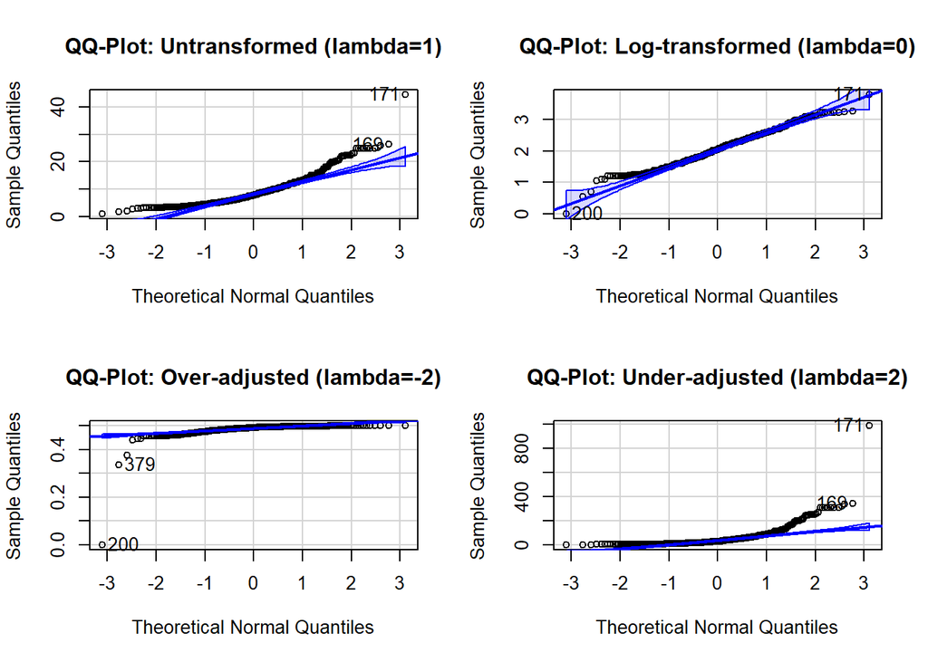

```
[1] 171 169
```

```r
## QQ-plot 4: Under-adjusted (lambda=2)
car::qqPlot(wage.lambda2,
            main="QQ-Plot: Under-adjusted (lambda=2)",
            xlab="Theoretical Normal Quantiles",
            ylab="Sample Quantiles")
```

```r
par(opar)  # Reset plotting parameters
```

The QQ-plot for $\lambda = 0$ shows data points following the diagonal line most closely, with nearly all points falling within the confidence bands. The other three transformations show substantial departures from the diagonal, confirming that log-transformation is the best choice.

- Is the transformation with $\lambda=-2.0$ over-compensating the inherent positive skewness in the `wage` variable? In addition, is the transformation with $\lambda=2.0$ under-compensating the inherent positive skewness in the `wage` variable?

*Your answer goes here*

### 1-b-5 answer

```r
## Comparative analysis of over/under-compensation
cat("Skewness Comparison:\n")
```

```
Skewness Comparison:
```

```r
cat("  Original (lambda=1):", round(skew.lambda1, 4), "\n")
```

```
  Original (lambda=1): 1.6878
```

```r
cat("  Lambda = -2.0:      ", round(skew.lambdaN2, 4), "\n")
```

```
  Lambda = -2.0:       -13.5811
```

```r
cat("  Lambda =  2.0:      ", round(skew.lambda2, 4), "\n")
```

```
  Lambda =  2.0:       5.2046
```

$\lambda = -2.0$ is over-compensating. The evidence is clear:

- **Original wage**: Skewness = 1.6878 (positive skew, right tail)
- $\lambda = -2.0$: Skewness = **-13.5811** (extreme negative skew, left tail)

The transformation **completely reversed** the skewness from positive to negative, and made it much worse (|-13.5811| >> |1.6878|). This is a classic case of overcorrection.

$\lambda = 2.0$ is under-compensating (even toward the opposite way).

- **Original wage**: Skewness = 1.6878 (positive skew)
- $\lambda = 2.0$: Skewness = **5.2046** (even stronger positive skew!)

Not only does the transformation fail to reduce the positive skewness, it actually **makes it worse** (5.2046 > 1.6878). This is because $\lambda > 1$ is designed to reduce **negative skewness**, not positive skewness. For positive skewness, we need $\lambda < 1$.

**Box-Cox Theory:**

- $\lambda < 1$: Reduces positive skewness ✓
- $\lambda = 1$: No transformation
- $\lambda > 1$: Reduces negative skewness (wrong direction for our data!)

Both $\lambda = -2.0$ and $\lambda = 2.0$ do not work well — one overshoots, the other goes in the wrong direction entirely.

# Task 2: Confidence Intervals [1 point]

Continue with the `CPS1985` data set for this task. To simplify things do *not* perform variable transformations.

[a] Run a bivariate regression of `wage` (dependent variable) on `experience` (independent variable) and interpret the model estimates. [0.25 points]

*Your answer goes here*

### 2-a answer

```r
library(AER)  # Load AER package for CPS1985 dataset
data(CPS1985)   # Load the dataset

## Bivariate regression of wage on experience
reg.wage <- lm(wage~experience, data=CPS1985)  # Calibrate regression model
summary(reg.wage)  # Display regression output
```

```
Call:
lm(formula = wage ~ experience, data = CPS1985)

Residuals:
   Min     1Q Median     3Q    Max
-8.247 -3.601 -1.111  2.332 36.084

Coefficients:
            Estimate Std. Error t value Pr(>|t|)
(Intercept)  8.37997    0.38895  21.545   <2e-16 ***
experience   0.03614    0.01793   2.016   0.0443 *
---
Signif. codes:  0 '***' 0.001 '**' 0.01 '*' 0.05 '.' 0.1 ' ' 1

Residual standard error: 5.124 on 532 degrees of freedom
Multiple R-squared:  0.007579,  Adjusted R-squared:  0.005714
F-statistic: 4.063 on 1 and 532 DF,  p-value: 0.04433
```

**Interpretation:**

The regression model estimates the relationship between wage (dependent variable) and experience (independent variable):

- **Intercept (β₀ = 8.38):** The estimated wage for a worker with zero years of experience (i.e., a new labor market entrant) is $8.38 per hour. While the intercept is statistically significant (p < 0.001), sometimes it mainly serves as a reference point and is not the primary focus of interpretation.
- **Slope (β₁ = 0.036):** Each additional year of experience is associated with an increase of $0.036 in hourly wage on average. This coefficient is statistically significant at the 0.05 level (p = 0.0443), providing evidence of a positive relationship between experience and wage.
- **Model Fit:** The R² = 0.0076 indicates that experience explains only 0.76% of the variation in wages. This very low R² suggests that experience alone is a weak predictor of wage, and many other factors (such as education, occupation, industry, etc.) likely play more important roles in determining wages.
- **Overall Model Significance:** The F-statistic (F = 4.063, p = 0.0443) indicates that the model is statistically significant overall, meaning the relationship between experience and wage is unlikely to be due to chance alone.
- **Residual Standard Error:** The residual standard error of 5.12 indicates that, after accounting for experience, the typical deviation of observed wages from the predicted wage is about $5.12 per hour.

In summary, while experience has a statistically significant positive effect on wage, it explains very little of the overall wage variation, suggesting that a multivariate model including additional explanatory variables would be more appropriate for understanding wage determination.

[b] Calculate the 95% confidence intervals around the estimated regression parameters. Can you draw the same conclusion as you did using the *t*-test in the `summary` output of task 2a? [0.25 points]

*Your answer goes here*

### 2-b answer

```r
## Calculate 95% confidence intervals around regression parameters
cbind("Coef"=coef(reg.wage), confint(reg.wage, level=0.95))
```

```
                  Coef        2.5 %     97.5 %
(Intercept) 8.37996643 7.6159012552 9.14403161
experience  0.03614037 0.0009190502 0.07136169
```

**Interpretation:**

The 95% confidence intervals for the regression parameters are:

- **Intercept:** [7.616, 9.144] - This interval does not include zero, indicating that we can be 95% confident the true population intercept lies within this range. The intercept is statistically significant at the 0.05 level.
- **Experience:** [0.0009, 0.0714] - This interval does not include zero, indicating that we can be 95% confident the true effect of experience on wage is positive and lies within this range. The experience coefficient is statistically significant at the 0.05 level.

**Comparison with t-test conclusions:**

We draw the same conclusions from the confidence intervals as we did from the t-tests in Task 2a:

1. **For the intercept:** The t-test showed p < 0.001 (highly significant). The 95% CI excludes zero, confirming that the intercept is significantly different from zero at the 0.05 significance level.
2. **For experience:** The t-test showed p = 0.0443 (significant at α = 0.05). The 95% CI excludes zero, confirming that the experience coefficient is significantly different from zero at the 0.05 significance level.

In general, a two-sided hypothesis test at significance level α = 0.05 and a (1-α) = 95% confidence interval provide equivalent information. If the 95% CI excludes zero, we reject H₀: β = 0 at the 0.05 level. Note that the CI for experience just barely excludes zero (lower bound = 0.0009), which is consistent with the marginal significance level (p = 0.0443) observed in the t-test.

In conclusion, both the t-test and confidence interval approaches lead to the same statistical inference: experience has a statistically significant positive effect on wage at the 0.05 significance level.

[c] Scatterplot both variables and add the *predicted regression line*. Calculate the lower and upper 90% confidence interval *for the regression point predictions* and *not* the line prediction and add these lines to your scatterplot. You may also want to enhance your plot by adding lines for the means of education and income as well as adding a title. [0.5 points]

*Your answer goes here*

### 2-c answer

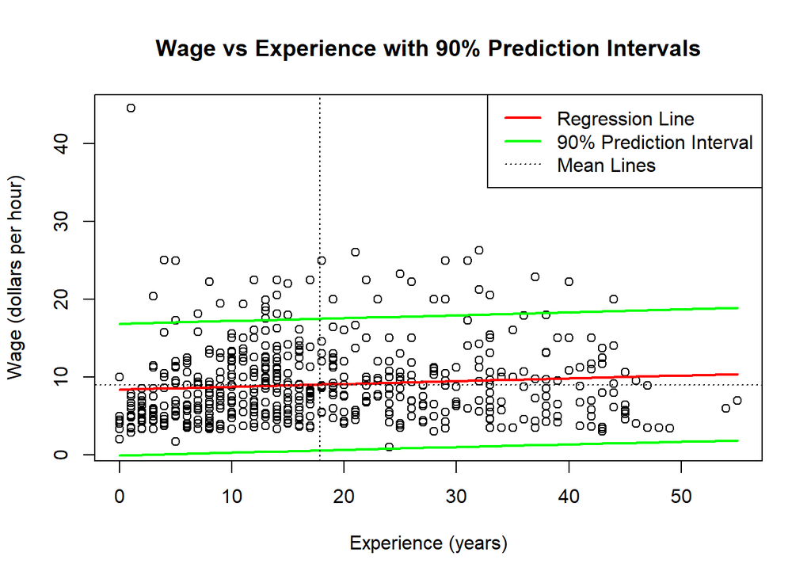

```r
## Scatterplot with regression line and 90% prediction intervals
# Note: Task asks for means of "education and income" but the model uses experience and wage

predDf <- data.frame(experience=min(CPS1985$experience):max(CPS1985$experience))
predDf <- data.frame(predDf,
                     predict(reg.wage, newdata=predDf,
                             interval="prediction", level=0.90))    # Point prediction interval

plot(wage~experience, data=CPS1985,
     xlab="Experience (years)",
     ylab="Wage (dollars per hour)",
     main="Wage vs Experience with 90% Prediction Intervals")
lines(predDf$experience, predDf$fit, col="red", lwd=2)              # Predicted regression line
lines(predDf$experience, predDf$lwr, col="green", lwd=2)            # Lower prediction interval
lines(predDf$experience, predDf$upr, col="green", lwd=2)            # Upper prediction interval
abline(h=mean(CPS1985$wage), v=mean(CPS1985$experience), lty=3)    # Mean reference lines


# Add a legend:
legend("topright",
       legend=c("Regression Line", "90% Prediction Interval", "Mean Lines"),
       col=c("red", "green", "black"),
       lty=c(1, 1, 3),
       lwd=c(2, 2, 1),
       bg="white")
```

**Graph Interpretation:** The scatterplot shows a very weak positive relationship between experience and wage, with a nearly flat regression line (red) and wide 90% prediction intervals (green), indicating that experience alone is a poor predictor of wage (p = 0.0443, which is statistically significant at the 0.05 level) and that substantial variation in wages remains unexplained by this single variable.

# Task 3: Bivariate Regression Model with Skewed Variables [4 points]

The `dBase` file `CampusCrime.dbf` has among other variables the count variables `crime` (number of crimes committed on university campuses) and `police` (size of the campuses police forces). Note: To import `dBase` files use the R-function `foreign::read.dbf( )`.

No need to show the functions, which are provided in class, in the sample script in your answers.

[a] Scatterplot `police` in dependence of `crime` including their box-plots along the margins. Is a data transformation advisable? [0.5 points]

*Your answer goes here*

### 3-a answer

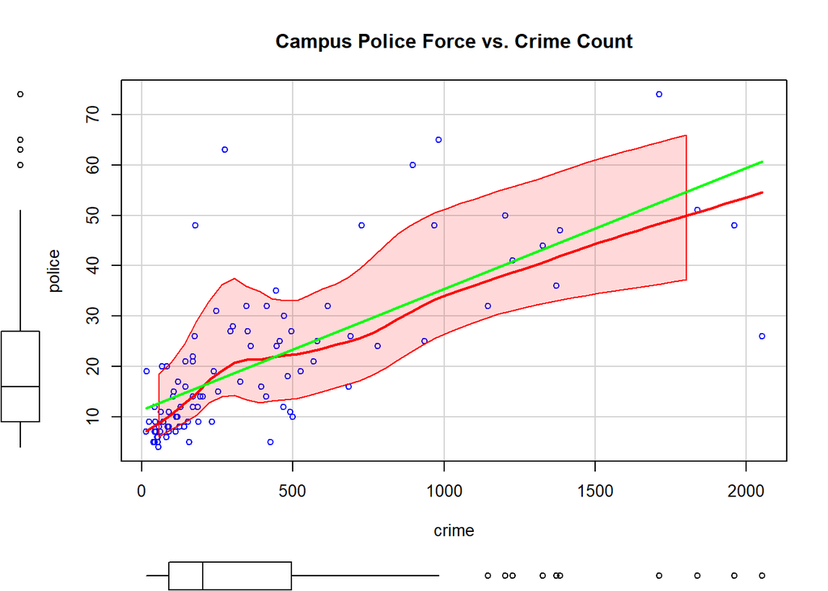

```r
library(car)
library(foreign)

# Import dBase file
CampusCrime <- foreign::read.dbf("CampusCrime.dbf")

# Scatterplot with marginal boxplots
car::scatterplot(police ~ crime, data = CampusCrime,
                 main = "Campus Police Force vs. Crime Count",
                 smooth = list(span = 0.5, lty.smooth = 1, col.smooth = "red", col.var = "red"),
                 regLine = list(col = "green"))
```

Based on the scatterplot with marginal boxplots, **data transformation is advisable** for several reasons:

1. **Positive skewness in both variables**: The marginal boxplots reveal that both `crime` (bottom) and `police` (left) are positively skewed. The boxes are compressed toward the lower end with long tails extending toward higher values, indicating that most observations cluster at low values with a few extreme cases.
2. **Non-linear relationship**: The lowess smoother (red) and the linear regression line (green) largely follow similar trends; however, modest deviations—particularly at higher crime values—suggest that a strictly linear specification may be inadequate and that potential non-linearity warrants consideration.
3. **Heteroscedasticity**: The vertical spread of data points increases systematically as crime increases. At low crime values (<500), observations cluster tightly, while at higher crime values (>1000), the scatter becomes much wider. This violates the constant variance assumption of linear regression.
4. **Clustering with outliers**: Most observations are concentrated in the lower-left region (low crime, low police), with several influential observations at higher values. These outliers can disproportionately affect regression estimates.

These patterns strongly suggest that Box-Cox transformations (likely log-transformations given the positive skewness and count nature of both variables) would help achieve:

- Symmetrically distributed variables
- A more linear relationship
- Homoscedastic residuals
- Reduced influence of extreme observations

[b] Find a proper transformation of both variables in a way that the independent variable `crime` is approximately symmetrically distributed and that the transformation of the dependent variable `police` leads to approximately symmetrically distributed regression residuals. [1 point]

*Your answer goes here*

### 3-b answer

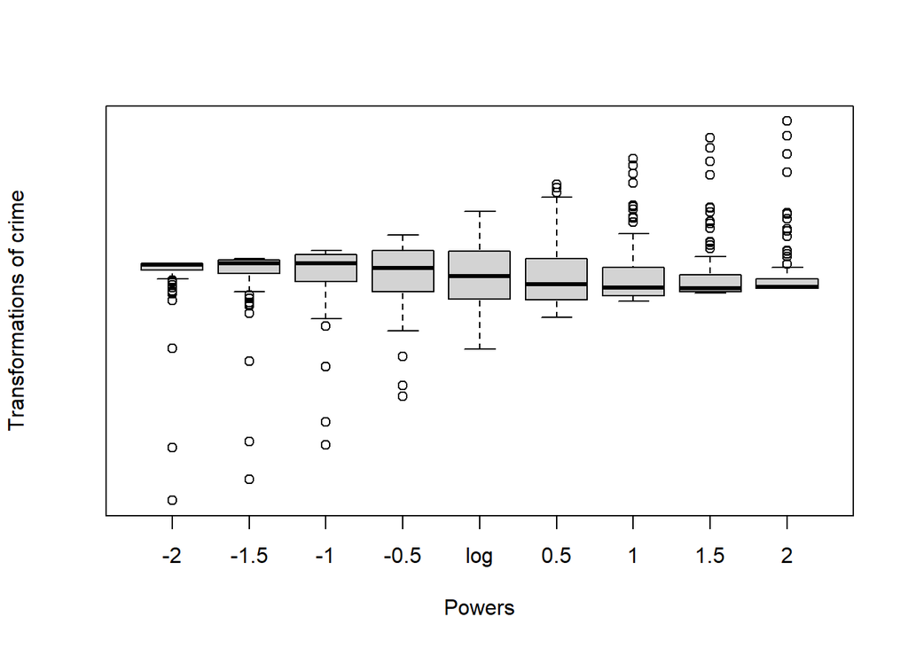

```r
# Explore transformations for independent variable (crime)
car::symbox(~crime, data = CampusCrime,
            powers = c(-2.0, -1.5, -1, -0.5, 0.0, 0.5, 1.0, 1.5, 2.0))
```

```r
# Find transformation for X (independent variable)
x.bc <- powerTransform(lm(crime ~ 1, data = CampusCrime))
(x.lambda <- x.bc$lambda)
```

```
        Y1
0.02579564
```

```r
summary(x.bc)
```

```
bcPower Transformation to Normality
   Est Power Rounded Pwr Wald Lwr Bnd Wald Upr Bnd
Y1    0.0258           0      -0.1444        0.196

Likelihood ratio test that transformation parameter is equal to 0
 (log transformation)
                             LRT df    pval
LR test, lambda = (0) 0.08843754  1 0.76617

Likelihood ratio test that no transformation is needed
                           LRT df       pval
LR test, lambda = (1) 107.9414  1 < 2.22e-16
```

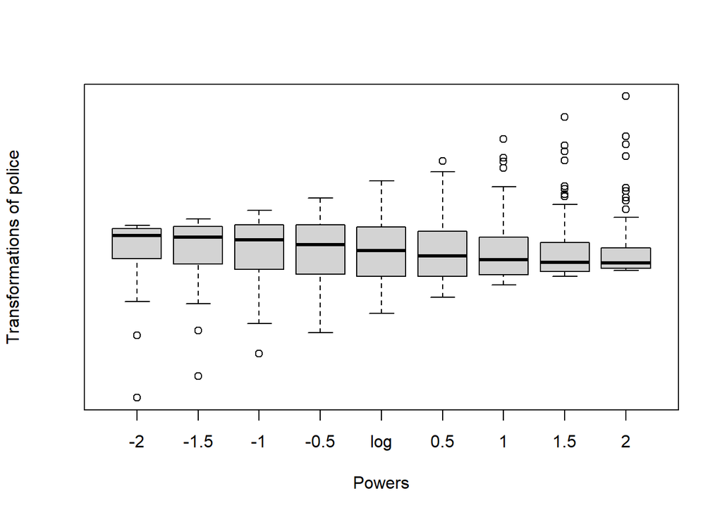

```r
# Explore transformations for dependent variable
car::symbox(~police, data = CampusCrime,
            powers = c(-2.0, -1.5, -1, -0.5, 0.0, 0.5, 1.0, 1.5, 2.0))
```

```r
# Find transformation for Y once X is transformed
y.bc <- powerTransform(lm(police ~ bcPower(crime, x.lambda), data = CampusCrime))
(y.lambda <- y.bc$lambda)
```

```
          Y1
0.0009474917
```

```r
summary(y.bc)
```

```
bcPower Transformation to Normality
   Est Power Rounded Pwr Wald Lwr Bnd Wald Upr Bnd
Y1     9e-04           0       -0.241       0.2429

Likelihood ratio test that transformation parameter is equal to 0
 (log transformation)
                               LRT df    pval
LR test, lambda = (0) 5.889249e-05  1 0.99388

Likelihood ratio test that no transformation is needed
                           LRT df       pval
LR test, lambda = (1) 62.87245  1 2.2204e-15
```

Based on the rigorous Box-Cox transformation approach, we find proper transformations for both variables.

**For the independent variable `crime`:**

The transformation aims to achieve approximate symmetry of the crime variable itself:

- **Estimated λ**: 0.0258
- **Rounded power**: 0 (log-transformation)
- **LR test for λ = 0**: p-value = 0.766 (not significant)
  - We **fail to reject** H₀: λ = 0, meaning log-transformation is statistically sufficient to achieve symmetry
- **LR test for λ = 1**: p-value < 0.001 (highly significant)
  - We **reject** H₀: λ = 1, confirming that the untransformed crime variable is inappropriate

The symbox plot confirms this result visually: at λ = 0 (log), the boxplot shows the most symmetric distribution with balanced whiskers and the median centered in the box.

**For the dependent variable `police`:**

Following the rigorous transformation approach (ref: BoxCoxBivariateRegression.r lines 88-89), we find the transformation that makes **regression residuals** approximately symmetrically distributed **conditional on the transformed crime variable**:

- **Estimated λ**: 0.0009
- **Rounded power**: 0 (log-transformation)
- **LR test for λ = 0**: p-value = 0.994 (not significant)
  - We **fail to reject** H₀: λ = 0, meaning log-transformation is sufficient for achieving symmetric **regression residuals**
- **LR test for λ = 1**: p-value < 0.001 (highly significant)
  - We **reject** H₀: λ = 1, confirming that untransformed police leads to asymmetric residuals

**Key point:** This transformation was determined using `lm(police ~ bcPower(crime, x.lambda))`, which ensures the residuals `e = police^(λ) - β₀ - β₁·crime^(x.lambda)` are approximately symmetric, not just the police variable itself.

The proper transformation for both variables is the **log-transformation** (λ = 0):

- **Transformed crime**: log(crime) - achieves symmetry of the independent variable
- **Transformed police**: log(police) - achieves symmetry of regression residuals

[c] Interpret the test whether a $log$-transformation (i.e., $\lambda=0$) is appropriate for both, the dependent and the independent, variables. [0.5 point]

**Important:** If the $log$-transformation is appropriate ($H_0:\lambda=0$ is *insignificant*) then *use it* because their relationship can now be interpreted in terms of *elasticities*.

*Your answer goes here*

### 3-c answer

As shown in 3-b, the LR tests for H₀: λ = 0 are insignificant for both variables (p = 0.766 for crime, p = 0.994 for police), meaning the log-transformation is statistically equivalent to the estimated optimal λ values. Meanwhile, the LR tests for H₀: λ = 1 are both highly significant (p < 0.001), confirming that transformation is necessary.

Since log-transformation is appropriate for both variables, we adopt the **log-log regression model**:

$$\log(\text{police}) = \beta_0 + \beta_1 \cdot \log(\text{crime}) + \varepsilon$$

This specification is advantageous because the slope $\beta_1$ can be interpreted as an **elasticity**: it represents the percentage change in police force size associated with a 1% change in crime count.

[d] Estimate the model in the transformed system and interpret the estimates. Also *test* if the elasticity (i.e., slope parameter) differs significantly from the neutral elasticity of 1, i.e., $H_0:\beta_1=1$. This could be done manually by using $\beta_1$’s standard error from the regression output or by using the function `car::linearHypothesis`. [1.5 point]

*Your answer goes here*

### 3-d answer

```r
## Estimate log-log model (using lambda=0 as justified in 3-c)
model.log <- lm(bcPower(police, 0) ~ bcPower(crime, 0), data=CampusCrime)
summary(model.log)
```

```
Call:
lm(formula = bcPower(police, 0) ~ bcPower(crime, 0), data = CampusCrime)

Residuals:
    Min      1Q  Median      3Q     Max
-1.4893 -0.2910 -0.0575  0.3301  1.3459

Coefficients:
                  Estimate Std. Error t value Pr(>|t|)
(Intercept)        0.27907    0.23950   1.165    0.247
bcPower(crime, 0)  0.46573    0.04326  10.766   <2e-16 ***
---
Signif. codes:  0 '***' 0.001 '**' 0.01 '*' 0.05 '.' 0.1 ' ' 1

Residual standard error: 0.4793 on 91 degrees of freedom
Multiple R-squared:  0.5602,    Adjusted R-squared:  0.5554
F-statistic: 115.9 on 1 and 91 DF,  p-value: < 2.2e-16
```

```r
# Test H0: beta1 = 1 (neutral elasticity)
# Method 1: Manual calculation
b1 <- coef(model.log)[2]
se.b1 <- summary(model.log)$coefficients[2, 2]
t.stat <- (b1 - 1) / se.b1             # for t-test calculation
df <- model.log$df.residual            # for degrees of freedom
p.value <- 2 * pt(abs(t.stat), df, lower.tail = FALSE)  # two-tailed test

cat("\n=== Test of Neutral Elasticity (H0: beta1 = 1) ===\n")
```

```
=== Test of Neutral Elasticity (H0: beta1 = 1) ===
```

```r
cat("Manual calculation:\n")
```

```
Manual calculation:
```

```r
cat("  t-statistic:", round(t.stat, 4), "\n")
```

```
  t-statistic: -12.3512
```

```r
cat("  p-value:", round(p.value, 4), "\n\n")
```

```
  p-value: 0
```

```r
# Method 2: Using car::linearHypothesis
linearHypothesis(model.log, "bcPower(crime, 0) = 1")
```

```
Linear hypothesis test:
bcPower(crime, 0) = 1

Model 1: restricted model
Model 2: bcPower(police, 0) ~ bcPower(crime, 0)

  Res.Df    RSS Df Sum of Sq      F    Pr(>F)
1     92 55.962
2     91 20.910  1    35.052 152.55 < 2.2e-16 ***
---
Signif. codes:  0 '***' 0.001 '**' 0.01 '*' 0.05 '.' 0.1 ' ' 1
```

**Model Estimation in Transformed System:**

The estimated log-log regression model is:

**log(police) = 0.279 + 0.466 · log(crime)**

**Interpretation of Estimates:**

**Intercept (β₀ = 0.279)**:

- This represents the expected log(police) when log(crime) = 0, which corresponds to crime = 1
- The intercept is not statistically significant and has limited substantive interpretation, as log(crime) = 0 corresponds to crime = 1, which lies at the boundary of the data
- In practical terms, this makes sense because universities with very low crime don’t necessarily have zero police presence

**Slope (β₁ = 0.466)**:

- This is the **elasticity** of police force size with respect to crime count
- **Interpretation**: A 1% increase in crime is associated with approximately a 0.47% increase in police force size
- The elasticity is highly statistically significant (t = 10.766, p < 0.001), indicating a strong positive relationship
- The R² = 0.56 means that about 56% of the variation in log(police) is explained by log(crime), which is a reasonably good fit

**Test of Neutral Elasticity (H₀: β₁ = 1):**

I tested whether the elasticity differs significantly from the neutral elasticity of 1 using two methods:

**Method 1 - Manual Calculation**:

- t-statistic = (0.466 - 1) / 0.0433 = -12.35
- p-value ≈ 0

**Method 2 - `car::linearHypothesis()`**:

- F-statistic = 152.55
- p-value < 0.001

**Both tests strongly reject H₀: β₁ = 1** (p < 0.001). The elasticity of 0.466 is **significantly less than 1**, indicating **decreasing returns to scale**.

[e] Perform a prediction in the original data units and plot the *median* and *expectation* curves. Interpret the plot both in terms of the median and expectation curves. [0.5 points]

*Your answer goes here*

### 3-e answer

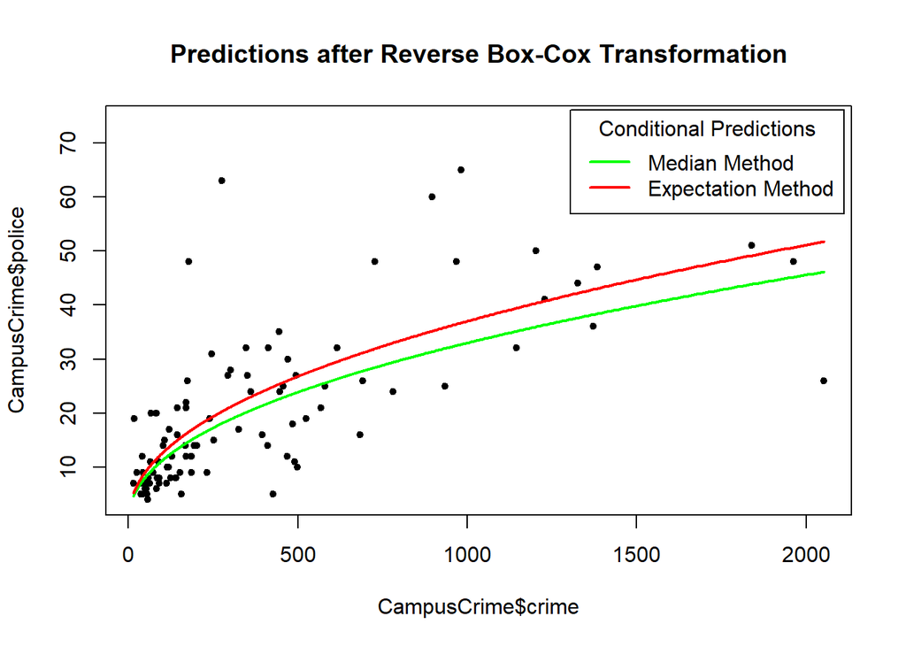

```r
# Define reverse transformation functions
bcReverseMedian <- function(y, lambda) {
  if (abs(lambda) < 1.0E-6)  # ref: BoxCoxBivariateRegression.r (line 10)
    rev.med <- exp(y) else
    rev.med <- (lambda * y + 1)^(1/lambda)
  return(rev.med)
}

bcReverseExpectation <- function(y, lambda, sigma) {
  if (abs(lambda) < 1.0E-6)  # ref: BoxCoxBivariateRegression.r (line 20)
    rev.exp <- exp(y + 0.5 * sigma) else
    rev.exp <- (lambda * y + 1)^(1/lambda) * (1 + 0.5 * sigma * (1 - lambda) / (lambda * y + 1)^2)
  return(rev.exp)
}

# Create prediction function
plotBoxCox <- function(y, x, ylambda = 1, xlambda = 1) {
  require(car)
  y.bc <- bcPower(y, ylambda)
  x.bc <- bcPower(x, xlambda)
  lm.mod <- lm(y.bc ~ x.bc)
  sigma <- sum(lm.mod$residuals^2) / (length(lm.mod$residuals) - 2)
  x.line <- data.frame(x.bc = seq(min(x.bc), max(x.bc), length.out = 1000))
  pred.line <- predict(lm.mod, x.line)
  y.med.line <- bcReverseMedian(pred.line, ylambda)
  y.exp.line <- bcReverseExpectation(pred.line, ylambda, sigma)
  x.med.line <- bcReverseMedian(x.line$x.bc, xlambda)
  plot(x, y, pch = 20,
       xlab = deparse(substitute(x)), ylab = deparse(substitute(y)),
       main = "Predictions after Reverse Box-Cox Transformation")
  lines(x.med.line, y.med.line, col = "green", lwd = 2)
  lines(x.med.line, y.exp.line, col = "red", lwd = 2)
  legend("topright", title = "Conditional Predictions", inset = 0.01, bg = "white",
         legend = c("Median Method", "Expectation Method"), col = c("green", "red"), lwd = 2)
  pred.pts <- predict(lm.mod)
  pred <- data.frame(y = y, y.pred.med = bcReverseMedian(pred.pts, ylambda),
                     y.pred.exp = bcReverseExpectation(pred.pts, ylambda, sigma), x = x)
  invisible(pred)
}

# Create the plot (lambda=0 for both variables)
plotBoxCox(CampusCrime$police, CampusCrime$crime, 0, 0)
```

The plot shows the predicted relationship between crime and police in original data units after reversing the log-transformation.

**Median curve (green):** Obtained by directly applying the inverse transformation $\text{median}(\text{police} | \text{crime}) = \exp(\hat{y}^{(0)})$. This preserves the robust properties of the transformed system and is less influenced by skewness and outliers.

**Expectation curve (red):** Accounts for the positive skewness that re-emerges after the inverse transformation by applying the correction $E(\text{police} | \text{crime}) = \exp(\hat{y}^{(0)} + 0.5\sigma^2)$. The expectation is consistently above the median because for any given crime level, the conditional distribution of police is positively skewed, and extreme high values pull the mean upward.

The gap between the two curves increases with crime level, reflecting increasing variance heterogeneity in the original measurement scale.

# Task 4: Numerical Integration [2 points]

Evaluate the three distance decay functions $p \in \{1,2,3\}$ along a line around the central reference point zero.
$$f_p\left(x\right)= \frac{1}{\exp{\left|x\right|^p}}$$
over their full theoretical distance range $-\infty\le x\le\infty$. Report the calculated integrals from tasks 4 a-c in a joint table. Also show your code.

[a] Plot these three functions within a reasonable value range of the distance $x$. Describe how does the shape of their curves change with increasing power? Note, for plotting purposes only you need to restrict the value range to say $-6\le x\le6$. Show the *clean* code for the tasks below. [0.5 points]

*Your answer goes here*

### 4-a answer

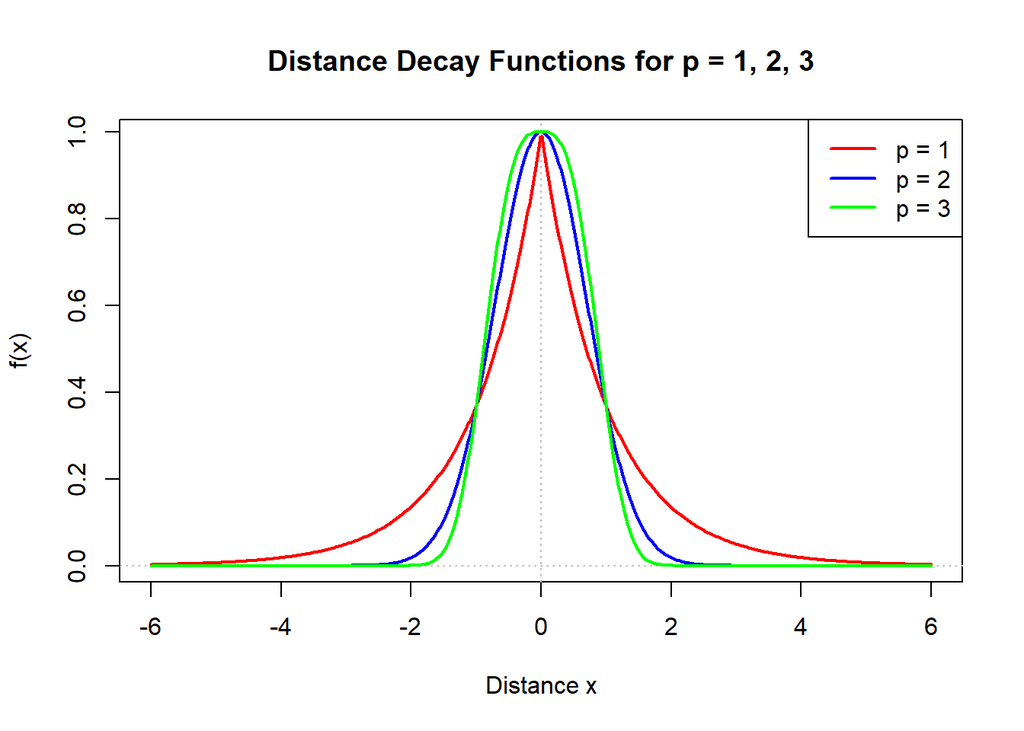

```r
## Define distance decay functions
f1 <- function(x) {
  1 / exp(abs(x)^1)
}

f2 <- function(x) {
  1 / exp(abs(x)^2)
}

f3 <- function(x) {
  1 / exp(abs(x)^3)
}

## Plot the three functions
x <- seq(-6, 6, length.out = 500)
plot(x, f1(x), type = "n", xlab = "Distance x", ylab = "f(x)",
     main = "Distance Decay Functions for p = 1, 2, 3")
abline(v = 0, lty = "dotted", col = "grey")
abline(h = 0, lty = "dotted", col = "grey")

lines(x, f1(x), col = "red", lwd = 2)
lines(x, f2(x), col = "blue", lwd = 2)
lines(x, f3(x), col = "green", lwd = 2)
legend("topright", legend = c("p = 1", "p = 2", "p = 3"),
       col = c("red", "blue", "green"), lwd = 2)
```

**Plot Description:**

From the plot, we observe how the shape of the distance decay functions changes as the power p increases from 1 to 3.

**Peak height**: All three functions attain the same maximum value at x = 0 (equal to 1). Increasing p does not change the peak height, but instead affects the rate at which the function declines away from the center.

**Tail behavior**: As p increases, the tails decay more rapidly. The p = 1 curve exhibits relatively heavy tails, maintaining non-negligible values at large distances, while the p = 3 curve approaches zero quickly.

**Overall shape**: The p = 1 function shows gradual exponential decay, p = 2 produces a smooth bell-shaped curve (similar in appearance to a normal distribution), and p = 3 results in a highly localized function with very light tails. All functions are symmetric around x = 0.

All three functions are symmetric around x = 0, which makes sense given the absolute value in the function definition.

In practical terms, higher p values represent phenomena where influence or impact drops off very quickly with distance, while lower p values represent more gradual distance decay effects.

[b] Evaluate the areas $A_1$, $A_2$ and $A_3$ underneath the three functions over their full support $-\infty\le x\le\infty$ with R’s `integrate( )`-function. The `integrate( )`-function allows to use infinity, i.e., `-Inf` and `Inf`, as upper and lower bounds. [0.5 points]

*Your answer goes here*

### 4-b answer

We evaluate the areas under the three distance decay functions over their full support from -∞ to +∞ using R’s `integrate()` function:

```r
## Evaluate areas underneath the three functions
A1 <- integrate(f1, -Inf, Inf)$value
A2 <- integrate(f2, -Inf, Inf)$value
A3 <- integrate(f3, -Inf, Inf)$value

## Display the results
cat("Area A1 (p=1):", A1, "\n")
```

```
Area A1 (p=1): 2
```

```r
cat("Area A2 (p=2):", A2, "\n")
```

```
Area A2 (p=2): 1.772454
```

```r
cat("Area A3 (p=3):", A3, "\n")
```

```
Area A3 (p=3): 1.785959
```

[c] Calculate the expectation $E_p\left(x\right)=\int_{-\infty}^{\infty}{x\cdot\frac{f_p(x)}{A_p}}\cdot dx$ for all three distance decay functions $p\in\left\{1,2,3\right\}$. [0.5 points]

*Why* do you need to divide $f_p\left(x\right)$ by $A_p$ to calculate the expectations and variances?

Could you guess the expectation by simply looking at the plot of the three curves?

*Your answer goes here*

### 4-c answer

```r
## Define integrand for expectation calculation
ExpectIntegrand <- function(x, p, A_p) {
  x * exp(-abs(x)^p) / A_p # Simplified: 1/exp(x) = exp(-x)
}

## Calculate expectations
E1 <- integrate(ExpectIntegrand, -Inf, Inf, p = 1, A_p = A1)$value
E2 <- integrate(ExpectIntegrand, -Inf, Inf, p = 2, A_p = A2)$value
E3 <- integrate(ExpectIntegrand, -Inf, Inf, p = 3, A_p = A3)$value

cat("Expectation E1 (p=1):", E1, "\n")
```

```
Expectation E1 (p=1): 0
```

```r
cat("Expectation E2 (p=2):", E2, "\n")
```

```
Expectation E2 (p=2): 0
```

```r
cat("Expectation E3 (p=3):", E3, "\n")
```

```
Expectation E3 (p=3): 0
```

**Results:**

- E₁ (p=1) ≈ 0 (numerically very close to zero, e.g., ~10⁻¹⁶)
- E₂ (p=2) ≈ 0
- E₃ (p=3) ≈ 0

**Why do we need to divide f_p(x) by A_p?**

$$\int_{-\infty}^{\infty} f(x) \, dx = 1$$

By dividing f_p(x) by its area A_p, we ensure this property holds:

$$\int_{-\infty}^{\infty} \frac{f_p(x)}{A_p} \, dx = \frac{A_p}{A_p} = 1$$

This normalization is essential because expectations and variances are defined for probability distributions, not just arbitrary functions. Without normalizing, the calculated “expectation” would not have the correct probabilistic interpretation.

Even though the mean is 0 by symmetry, dividing by A_p is necessary to make the function a proper pdf so that expectations/variances are defined on a probabilistic scale and are comparable across p.

**Could we guess the expectation from the plot?**

Yes. By looking at the plot from part (a), we can predict that all three expectations equal zero. The reason is clear: all three functions are perfectly symmetric around x = 0.

For any symmetric distribution centered at zero:

- The negative values (left side, x < 0) have the same probability weights as their corresponding positive values (right side, x > 0)
- When we calculate
  $$E(X) = \int_{-\infty}^{\infty} x \cdot f(x) \, dx$$
  , the negative contributions exactly cancel out the positive contributions
- Therefore,
  $$E_1 = E_2 = E_3 = 0$$

The numerical results confirm this visual intuition.

[d] Calculate the variances ${Var}_p\left(x\right)=\int_{-\infty}^{\infty}{\left(x-E_p(x)\right)^2\cdot\frac{f_p(x)}{A_p}}\cdot dx$ for all three distance decay functions $p\in\left\{1,2,3\right\}$. [0.5 points]

*Your answer goes here*

### 4-d answer

```r
## Define integrand for variance calculation
VarIntegrand <- function(x, p, E_p, A_p) {
  (x - E_p)^2 * exp(-abs(x)^p) / A_p
}

## Calculate variances
Var1 <- integrate(VarIntegrand, -Inf, Inf, p = 1, E_p = E1, A_p = A1)$value
Var2 <- integrate(VarIntegrand, -Inf, Inf, p = 2, E_p = E2, A_p = A2)$value
Var3 <- integrate(VarIntegrand, -Inf, Inf, p = 3, E_p = E3, A_p = A3)$value

## Create summary table
results <- data.frame(
  p = c(1, 2, 3),
  Area = c(A1, A2, A3),
  Expectation = c(E1, E2, E3),
  Variance = c(Var1, Var2, Var3)
)
print(results)
```

```
  p     Area Expectation  Variance
1 1 2.000000           0 2.0000000
2 2 1.772454           0 0.5000000
3 3 1.785959           0 0.3732822
```

**Interpretation:**

The variance measures the spread or dispersion of a distribution around its center (the expectation). It represents the average squared distance of values from the mean.

From our results, we observe a clear pattern:

$$\text{Var}_1 (2.000) > \text{Var}_2 (0.500) > \text{Var}_3 (0.373)$$

This result perfectly aligns with what we observed visually in part (a):

The decreasing variance with increasing p quantitatively confirms our observation from the plot: higher p values produce more peaked, concentrated distributions.

**Hints:** In R the professional integration function is `integrate( )`. [i]Study the online help for this functions. [ii] To learn how to properly setup the functions to be integrated (aka, integrand), see for example the `RiemannSum.R` or the online help of the `integrate( )`-function. [iii] The `integrate( )`-function is more robust and may accept as upper and lower bounds the parameters `Inf` and `-Inf` rather than arbitrary lower and upper truncation points. [iv] Additional parameters, other than $x$, to the integrand function, such as $A_p$ or $E_p(x)$, can be passed in the `integrate( )`-function using its placeholder argument `...`. See the online help for the function `integrate( )`.